# Cross-Validation

Notes and in-class exercises

You can download the .qmd file for this activity here and open in R-studio. The rendered version is posted in the [course website](https://mutasim221b.github.io/Mac-STAT-253-Sp-26/) (Activities tab). I often experiment with the class activities (and see it in live!) and make updates, but I always post the final version before class starts. To be sure you have the most up-to-date copy, please download it once you’ve settled in before class begins.

# Learning Goals

- Accurately describe all steps of cross-validation to estimate the test/out-of-sample version of a model evaluation metric
- Explain what role CV has in a predictive modeling analysis and its connection to overfitting
- Explain the pros/cons of higher vs. lower k in k-fold CV in terms of sample size and computing time
- Implement cross-validation in R using the `tidymodels` package
- Use these tools and concepts to inform and justify data analysis and modeling process

# Notes: Cross-Validation

## Context: Evaluating Regression Models

A reminder of our current context:

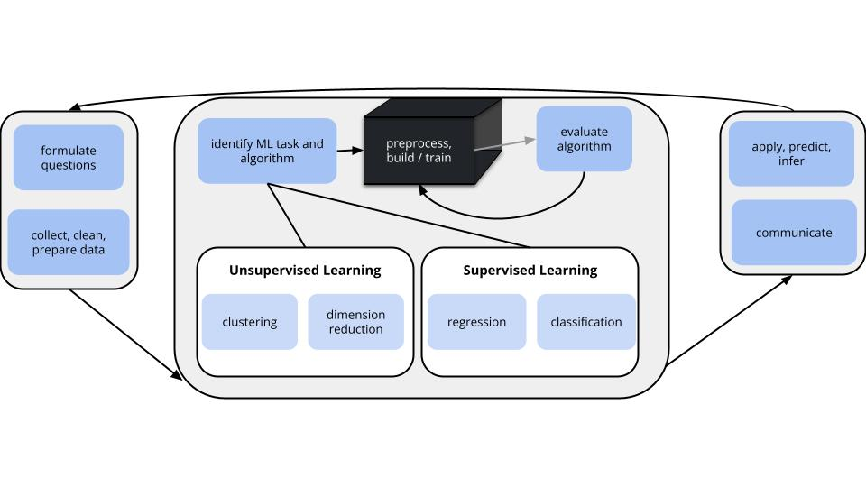

- **world = supervised learning**  
  We want to model some output variable $y$ by some predictors $x$.
- **task = regression**  
  $y$ is quantitative
- **model = linear regression model via least squares algorithm**  
  We’ll assume that the relationship between $y$ and $x$ can be represented by

  $$y = \beta_0 + \beta_1 x_1 + \beta_2 x_2 + ... + \beta_p x_p + \varepsilon$$

**GOAL: model evaluation**

We want more **honest** metrics of prediction quality that

1. assess how well our model predicts **new outcomes**; and
2. help prevent **overfitting**.

[figure not shown]

## Why is overfitting so bad?

Not only can overfitting produce misleading models, it can have serious societal impacts.

Examples:

- Facial recognition algorithms are often *overfit* to the people who build them (who are not broadly representative of society). As one example, this has led to [disproportionate bias in policing](https://www.nytimes.com/2019/07/08/us/detroit-facial-recognition-cameras.html). For more on this topic, you might check out [Coded Bias](https://www.youtube.com/watch?v=jZl55PsfZJQ), a documentary by Shalini Kantayya which features MIT Media Lab researcher Joy Buolamwini.
- Polygenic risk scores (PRSs), which aim to predict a person’s risk of developing a particular disease/trait based on their genetics, are often *overfit* to the data on which they are built (which, historically, has exclusively—or at least primarily—included individuals of European ancestry). As a result, PRS predictions tend to be more accurate in European populations and new research suggests that their [continued use in clinical settings could exacerbate health disparities](https://www.ncbi.nlm.nih.gov/pmc/articles/PMC6563838/).
- There are connections to overfitting in the article for the ethics reflection on HW1 (about [a former Amazon recruiting algorithm](https://www.reuters.com/article/us-amazon-com-jobs-automation-insight/amazon-scraps-secret-ai-recruiting-tool-that-showed-bias-against-women-idUSKCN1MK08G).

## k-Fold Cross Validation

We can use **k-fold cross-validation** to estimate the typical error in our model predictions for *new* data:

- Divide the data into $k$ folds (or groups) of approximately equal size.
- Repeat the following procedures for each fold $j = 1,2,...,k$:
  - Remove fold $j$ from the data set.
  - Fit a model using the data in the other $k-1$ folds (training).
  - Use this model to predict the responses for the $n_j$ cases in fold $j$: $\hat{y}_1, ..., \hat{y}_{n_j}$.
  - Calculate the MAE for fold $j$ (testing): $\text{MAE}_j = \frac{1}{n_j}\sum_{i=1}^{n_j} |y_i - \hat{y}_i|$.
- Combine this information into one measure of model quality:
  $$\text{CV}_{(k)} = \frac{1}{k} \sum_{j=1}^k \text{MAE}_j$$

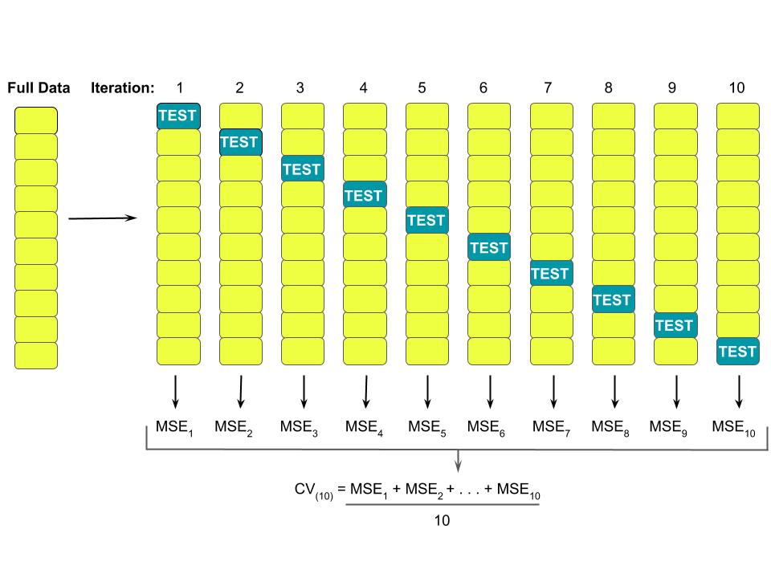

# Small Group Discussion

Algorithms and Tuning

## Definitions

- **algorithm** = a step-by-step procedure for solving a problem (Merriam-Webster)
- **tuning parameter** = a *parameter* or *quantity* upon which an algorithm depends, that must be *selected* or *tuned* to “optimize” the algorithm

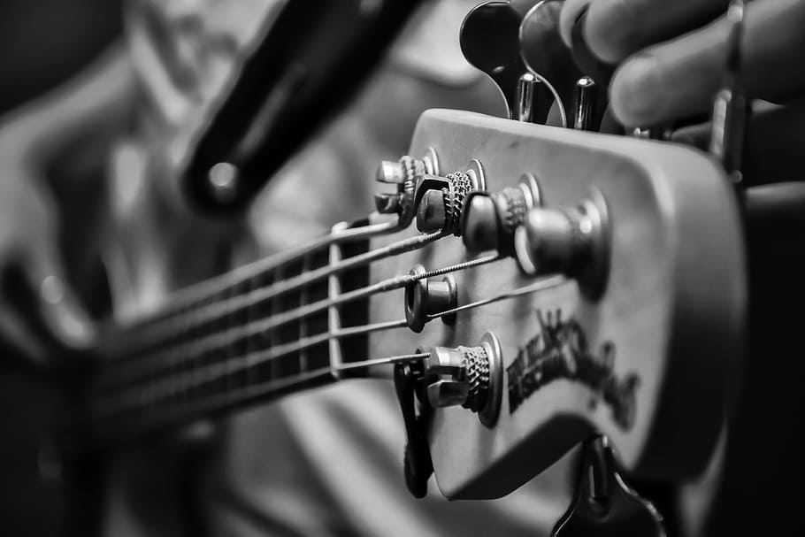

[^1]

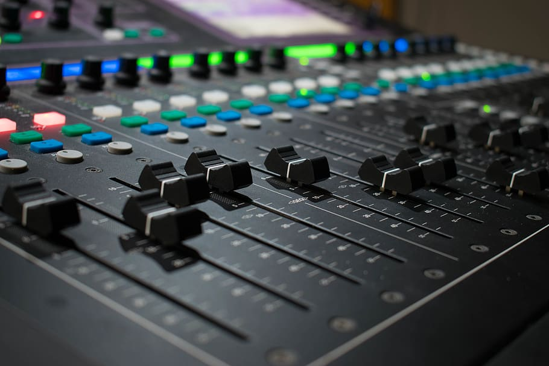

## Prompts

1. **Synchronize as a Team!**
2. **Conceptual check**
1. Why is $k$-fold cross-validation an *algorithm*?

> It follows a list of steps to get to its goal.
2. What is the *tuning parameter* of this algorithm and what values can this take?

> $k$, the number of folds, is a tuning parameter. $k$ can be any integer from 2, …, $n$ where $n$ is our sample size.

**SPECIAL CASE:** Leave One Out Cross-Validation (LOOCV).

LOOCV is a special case of k-fold cross-validation in which, in each iteration, we hold out **one** data point as a test case and use the other $n-1$ data points for training. Thus LOOCV is equivalent to $k = n$ fold CV.

[output not shown]

[output not shown]

3. How is 2-fold cross-validation (CV) different from *validation*? (*Validation* is what we did last class: splitting our sample into a training dataset and a testing dataset.)

> We use both groups as training and testing, in turn.
4. Why might 3-fold CV be better than 2-fold CV?

> We have a larger dataset to train our model on. We are less likely to get an unrepresentative set as our training data. We are also averaging our overall cross-validated MAE estimate over more testing folds, which is likely to result in a more stable estimate of out-of-sample error.
5. Why might LOOCV (leave-one-out CV) (k-fold CV where k = sample size) be worse than 3-fold cross-validation?

> Prediction error for 1 person is highly variable. Also, for computational time reasons, fitting models can be very slow.
6. In practice, $k = 10$ and $k=7$ are common choices for cross-validation. This has been shown to hit the ‘sweet spot’ between the extremes of $k=n$ (LOOCV) and $k=2$.
- $k=2$ only utilizes 50% of the data for each training model, thus might result in overestimating the prediction error
- $k=n$ leave-one-out cross-validation (LOOCV) requires us to build $n$ training models, thus might be computationally expensive for larger sample sizes $n$. Further, with only one data point in each test set, the training sets have a lot of overlap. This correlation among the training sets can make the ultimate corresponding estimate of prediction error less reliable.
3. **R Code Preview**

We’ve been doing a 2-step process to build **linear regression models** using the **tidymodels** package:

```r
# STEP 1: model specification
lm_spec <- linear_reg() %>%
  set_mode("regression") %>%
  set_engine("lm")

# STEP 2: model estimation
my_model <- lm_spec %>%
  fit(
    y ~ x1 + x2,
    data = sample_data
  )
```

For k-fold cross-validation, we can *tweak* STEP 2. Discuss the code below:

- What’s similar? What’s different? > Similar to fit(), we tell the function fit_resamples what model to fit and which data to use. But, instead of fitting that model once to the full data, we use CV.
- What do you think each new, or otherwise modified, line does?
- Why do we need `set.seed`?

```r
set.seed(___) # set seed for reproducibility

my_model_cv <- lm_spec %>% # take the model specs we defined earlier, and then

  fit_resamples( # fit multiple models (across multiple resamples of the data)

    y ~ x1 + x2, # the model we want to fit

    resamples = vfold_cv(sample_data, v = ___), # use "v"-fold CV to create the resamples (fill in the blank to specify "v", aka "k")

    metrics = metric_set(mae, rsq) # specify which evaluation metric(s) (MAE, R^2) to use

  )
```

Here are a few general tips for breaking down complex code:

- Read the R Documentation / help page for any new functions (eg type `?fit_resamples` into the Console)
- Try removing or otherwise modifying each line of code and see what happens!

*Why set a seed?* The process of creating the folds is random, so we should set the seed to have reproducibility within our work.

# Notes: R Code

**Reminder**

This section is for **future** reference. It is a summary of code you’ll learn below for doing k-fold cross-validation. You do not need to (and in fact should not) run the code in this section verbatim in R; it is example code and meant for future reference only.

Suppose we wish to build and evaluate a linear regression model of `y` vs `x1` and `x2` using our `sample_data`.

**Load the appropriate packages**

```r
# Load packages
library(tidyverse)
library(tidymodels)
```

**Obtain k-fold cross-validated estimates of MAE and $R^2$**

(Review above for discussion of these steps.)

```r
# model specification
lm_spec <- linear_reg() %>%
  set_mode("regression") %>%
  set_engine("lm")

# k-fold cross-validation
# For "v", put your number of folds k
set.seed(___)
model_cv <- lm_spec %>%
  fit_resamples(
    y ~ x1 + x2,
    resamples = vfold_cv(sample_data, v = ___),
    metrics = metric_set(mae, rsq)
)
```

**Obtain the cross-validated metrics**

```r
model_cv %>%
  collect_metrics()
```

**Get the MAE and R-squared for each test fold**

```r
# MAE for each test fold: Model 1
model_cv %>%
  unnest(.metrics)
```

# Exercises

## Instructions

- Go to the Course Schedule and find the QMD template for today
  - Save this in your STAT 253 Notes folder, NOT your downloads!
- Work through the exercises implementing CV to compare two possible models predicting `height`
- Same directions as before:
  - Be kind to yourself/each other
  - **Collaborate**
  - DON’T edit starter code (i.e., code with blanks `___`). Instead, copy-paste into a new code chunk below and edit from there.
- Ask me questions as I move around the room

## Questions

```r
# Load packages and data
library(tidyverse)
library(tidymodels)
humans <- read.csv("https://Mac-Stat.github.io/data/bodyfat50.csv") %>%
  filter(ankle < 30) %>%
  rename(body_fat = fatSiri)
```

1. **Review: In-sample metrics**- As Group

Use the `humans` data to build two separate models of `height`:

```r
# STEP 1: model specification
lm_spec <- ___() %>%
  set_mode(___) %>%
  set_engine(___)
```

```r
# STEP 2: model estimation
model_1 <- ___ %>%
  ___(height ~ hip + weight + thigh + knee + ankle, data = humans)
model_2 <- ___ %>%
  ___(height ~ chest * age * weight * body_fat + abdomen + hip + thigh + knee + ankle + biceps + forearm + wrist, data = humans)
```

Calculate the **in-sample** R-squared for both models:

```r
# IN-SAMPLE R^2 for model_1 = ???
model_1 %>%
  ___()
```

```r
# IN-SAMPLE R^2 for model_2 = ???
model_2 %>%
  ___()
```

Calculate the **in-sample** MAE for both models:

```r
# IN-SAMPLE MAE for model_1 = ???
model_1 %>%
  ___(new_data = ___) %>%
  mae(truth = ___, estimate = ___)
```

```r
# IN-SAMPLE MAE for model_2 = ???
model_2 %>%
  ___(new_data = ___) %>%
  mae(truth = ___, estimate = ___)
```

2. **In-sample model comparison** - As Group

Which model seems “better” by the in-sample metrics you calculated above? Any concerns about either of these models?

> Type your answer
3. **10-fold CV** - As Group

Complete the code to run 10-fold cross-validation for our two models.

Model 1: `height ~ hip + weight + thigh + knee + ankle`  
Model 2: `height ~ chest * age * weight * body_fat + abdomen + hip + thigh + knee + ankle + biceps + forearm + wrist`

```r
# 10-fold cross-validation for model_1
set.seed(253)
model_1_cv <- ___ %>%
  ___(
    ___,
    ___ = vfold_cv(___, v = ___),
    ___ = metric_set(mae, rsq)
  )
```

```r
# 10-fold cross-validation for model_2
set.seed(253)
model_2_cv <- ___ %>%
  ___(
    ___,
    ___ = vfold_cv(___, v = ___),
    ___ = metric_set(mae, rsq)
  )
```

4. **Calculating the CV MAE** - As Group
1. Use `collect_metrics()` to obtain the cross-validated MAE and $R^2$ for both models.

```r
# HINT
___ %>%
  collect_metrics()
```

2. Interpret the cross-validated MAE *and* $R^2$ for `model_1`.
5. **Details: fold-by-fold results** - As Group

The `collect_metrics()` function gave the final CV MAE, or the average MAE across all 10 test folds. If you want the MAE from *each* test fold, try `unnest(.metrics)`.

1. Obtain the fold-by-fold results for the `model_1` cross-validation procedure using `unnest(.metrics)`.

```r
# HINT
___ %>%
  unnest(.metrics)
```

2. Which fold had the worst average prediction error and what was it?
3. Recall that `collect_metrics()` reported a final CV MAE of 1.87 for `model_1`. Confirm this calculation by wrangling the fold-by-fold results from part a.
6. **Comparing models** - As Team

The table below summarizes the in-sample and 10-fold CV MAE for both models.

| Model | IN-SAMPLE MAE | 10-fold CV MAE |
| --- | --- | --- |
| `model_1` | 1.55 | 1.87 |
| `model_2` | 0.64 | 2.47 |

1. Based on the in-sample MAE alone, which model appears better?

> model_2
2. Based on the CV MAE alone, which model appears better?

> model_1
3. Based on all of these results, which model would you pick?

> model_1 – model_2 produces bad predictions for new adults
4. Do the in-sample and CV MAE suggest that `model_1` is overfit to our `humans` sample data? What about `model_2`? Why/why not?

> model_1 is NOT overfit – its predictions of height for new adults seem roughly as accurate as the predictions for the adults in our sample. model_2 IS overfit – its predictions of height for new adults are worse than the predictions for the adults in our sample.
7. **LOOCV**- As Team

No code to implement for this exercise–just answer the following conceptually.

1. How could we adapt the code in Exercise 3 to use LOOCV MAE instead of the 10-fold CV MAE?

There are 39 people in our sample, thus LOOCV is equivalent to 39-fold CV:

```r
nrow(humans)
model_1_loocv <- lm_spec %>%
  fit_resamples(
    height ~ hip + weight + thigh + knee + ankle,
    resamples = vfold_cv(humans, v = nrow(humans)), # this will throw an error and tell you to use loo_cv() instead
    metrics = metric_set(mae)
  )

model_1_loocv %>%
  collect_metrics()
```

2. Why do we technically not *need* to `set.seed()` for the LOOCV algorithm?

> There’s no randomness in the test folds. Each test fold is a single person.
8. **Additional Exercise: Data drill**
1. Calculate the average height of people under 40 years old vs people 40+ years old.
2. Plot height vs age among our subjects that are 30+ years old.
3. Fix this code:

```r
model_3<-lm_spec%>%fit(height~age,data=humans)
model_3%>%tidy()
```

9. **Reflection: Part 1**

The “regular” exercises are over, but class is not done! Your group should agree to either work on HW1 or the remaining reflection questions.

*This is the end of Unit 1 on “Regression: Model Evaluation”!* Let’s reflect on the technical content of this unit:

- What was the main motivation / goal behind this unit?
- What are the four main questions that were important to this unit?
- For each of the following tools, describe how they work and what questions they help us address:
  - R-squared
  - residual plots
  - out-of-sample MAE
  - in-sample MAE
  - validation
  - cross-validation
- In your own words, define the following:
  - overfitting
  - algorithm
  - tuning parameter
- Review the new `tidymodels` syntax from this unit. Identify key themes and patterns.

# Wrapping Up

## Today’s Material

- If you didn’t finish the exercises, no problem! Be sure to complete them outside of class, review the solutions on the course site, and ask any outstanding questions on Discussion board on Moodle or in office hours.
- **This is the end of Unit 1,** so there are *reflection questions* at the end of the exercises to help you organize the concepts in your mind. This is a good time to **pause**, review the material we’ve covered so far, and stop by office hours with any questions!
- An R tutorial video, talking through the new code, is posted on class schedule.

## Upcoming Deadlines

- CP4:
  - due 10 minutes before our next class
- HW1:
  - due Sunday, 02/08 at 11:59 pm
  - you have everything you need to finish this assignment after today’s class!
  - review the homework and late work/extension policies on Syllabus: deadline is so we can get timely feedback to you; three 3-day extensions to acknowledge “life happens”.

# Solutions

## Exercises

1. **Review: In-sample metrics**

**Solution**

```r
# STEP 1: model specification
lm_spec <- linear_reg() %>%
  set_mode("regression") %>%
  set_engine("lm")

# STEP 2: model estimation
model_1 <- lm_spec %>%
  fit(height ~ hip + weight + thigh + knee + ankle, data = humans)
model_2 <- lm_spec %>%
  fit(height ~ chest * age * weight * body_fat + abdomen + hip + thigh + knee + ankle + biceps + forearm + wrist, data = humans)

# IN-SAMPLE R^2 for model_1 = 0.40
model_1 %>%
  glance()
## # A tibble: 1 × 12
##   r.squared adj.r.squared sigma statistic p.value    df logLik   AIC   BIC
##       <dbl>         <dbl> <dbl>     <dbl>   <dbl> <dbl>  <dbl> <dbl> <dbl>
## 1     0.401         0.310  1.98      4.42 0.00345     5  -78.8  172.  183.
## # ℹ 3 more variables: deviance <dbl>, df.residual <int>, nobs <int>

# IN-SAMPLE R^2 for model_2 = 0.87
model_2 %>%
  glance()
## # A tibble: 1 × 12
##   r.squared adj.r.squared sigma statistic p.value    df logLik   AIC   BIC
##       <dbl>         <dbl> <dbl>     <dbl>   <dbl> <dbl>  <dbl> <dbl> <dbl>
## 1     0.874         0.680  1.35      4.51 0.00205    23  -48.4  147.  188.
## # ℹ 3 more variables: deviance <dbl>, df.residual <int>, nobs <int>

# IN-SAMPLE MAE for model_1 = 1.55
model_1 %>%
  augment(new_data = humans) %>%
  mae(truth = height, estimate = .pred)
## # A tibble: 1 × 3
##   .metric .estimator .estimate
##   <chr>   <chr>          <dbl>
## 1 mae     standard        1.55

# IN-SAMPLE MAE for model_2 = 0.64
model_2 %>%
  augment(new_data = humans) %>%
  mae(truth = height, estimate = .pred)
## # A tibble: 1 × 3
##   .metric .estimator .estimate
##   <chr>   <chr>          <dbl>
## 1 mae     standard       0.646
```

2. **In-sample model comparison**

**Solution**

The in-sample metrics are better for `model_2`, but from experience in our previous class, we should expect this to be overfit.

3. **10-fold CV**

**Solution**

```r
# 10-fold cross-validation for model_1
set.seed(253)
model_1_cv <- lm_spec %>%
  fit_resamples(
    height ~ hip + weight + thigh + knee + ankle,
    resamples = vfold_cv(humans, v = 10),
    metrics = metric_set(mae, rsq)
  )

# STEP 2: 10-fold cross-validation for model_2
set.seed(253)
model_2_cv <- lm_spec %>%
  fit_resamples(
    height ~ chest * age * weight * body_fat + abdomen + hip + thigh + knee + ankle + biceps + forearm + wrist,
    resamples = vfold_cv(humans, v = 10),
    metrics = metric_set(mae, rsq)
  )
```

4. **Calculating the CV MAE**

**Solution**

```r
# model_1
# CV MAE = 1.87, CV R-squared = 0.41
model_1_cv %>%
  collect_metrics()
## # A tibble: 2 × 6
##   .metric .estimator  mean     n std_err .config
##   <chr>   <chr>      <dbl> <int>   <dbl> <chr>
## 1 mae     standard   1.87     10   0.159 pre0_mod0_post0
## 2 rsq     standard   0.409    10   0.124 pre0_mod0_post0

# model_2
# CV MAE = 2.47, CV R-squared = 0.53
model_2_cv %>%
  collect_metrics()
## # A tibble: 2 × 6
##   .metric .estimator  mean     n std_err .config
##   <chr>   <chr>      <dbl> <int>   <dbl> <chr>
## 1 mae     standard   2.47     10   0.396 pre0_mod0_post0
## 2 rsq     standard   0.526    10   0.122 pre0_mod0_post0
```

2. We expect our first model to explain roughly 40% of variability in height among new adults, and to produce predictions of height (for new adults) that are off by 1.9 inches on average.
5. **Details: fold-by-fold results**

**Solution**

```r
# a. model_1 MAE for each test fold
model_1_cv %>%
  unnest(.metrics) %>%
  filter(.metric == "mae")
## # A tibble: 10 × 7
##    splits         id     .metric .estimator .estimate .config         .notes
##    <list>         <chr>  <chr>   <chr>          <dbl> <chr>           <list>
##  1 <split [35/4]> Fold01 mae     standard        2.22 pre0_mod0_post0 <tibble>
##  2 <split [35/4]> Fold02 mae     standard        2.34 pre0_mod0_post0 <tibble>
##  3 <split [35/4]> Fold03 mae     standard        2.56 pre0_mod0_post0 <tibble>
##  4 <split [35/4]> Fold04 mae     standard        1.51 pre0_mod0_post0 <tibble>
##  5 <split [35/4]> Fold05 mae     standard        1.81 pre0_mod0_post0 <tibble>
##  6 <split [35/4]> Fold06 mae     standard        2.43 pre0_mod0_post0 <tibble>
##  7 <split [35/4]> Fold07 mae     standard        1.61 pre0_mod0_post0 <tibble>
##  8 <split [35/4]> Fold08 mae     standard        1.84 pre0_mod0_post0 <tibble>
##  9 <split [35/4]> Fold09 mae     standard        1.28 pre0_mod0_post0 <tibble>
## 10 <split [36/3]> Fold10 mae     standard        1.10 pre0_mod0_post0 <tibble>

# b. fold 3 had the worst error (2.56)

# c. use these metrics to confirm the 1.87 CV MAE for model_1
model_1_cv %>%
  unnest(.metrics) %>%
  filter(.metric == "mae") %>%
  summarize(mean(.estimate))
## # A tibble: 1 × 1
##   `mean(.estimate)`
##               <dbl>
## 1              1.87
```

6. **Comparing models**

**Solution**

The table below summarizes the in-sample and 10-fold CV MAE for both models.

| Model | IN-SAMPLE MAE | 10-fold CV MAE |
| --- | --- | --- |
| `model_1` | 1.55 | 1.87 |
| `model_2` | 0.64 | 2.47 |

1. Based on the in-sample MAE alone, which model appears better?

> model_2
2. Based on the CV MAE alone, which model appears better?

> model_1
3. Based on all of these results, which model would you pick?

> model_1 – model_2 produces bad predictions for new adults
4. Do the in-sample and CV MAE suggest that `model_1` is overfit to our `humans` sample data? What about `model_2`? Why/why not?

> model_1 is NOT overfit – its predictions of height for new adults seem roughly as accurate as the predictions for the adults in our sample. model_2 IS overfit – its predictions of height for new adults are worse than the predictions for the adults in our sample.
8. **Data drill**

**Solution**

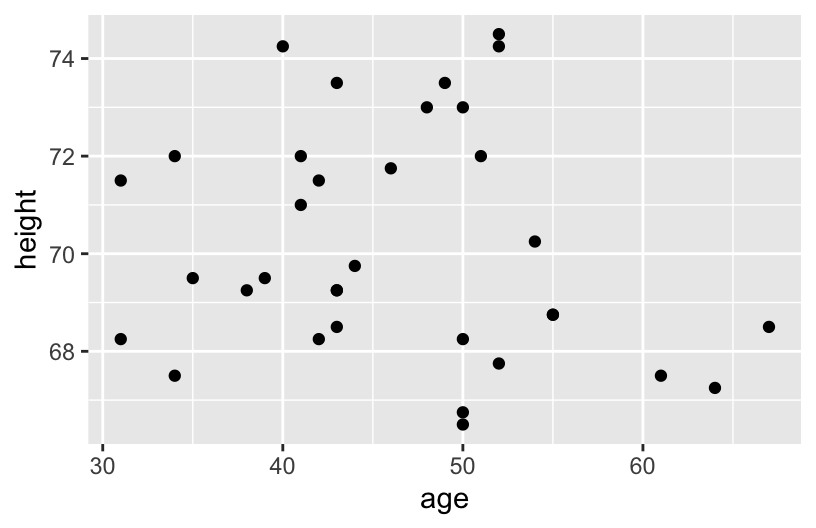

```r
# a (one of many solutions)
humans %>%
  mutate(younger_older = age < 40) %>%
  group_by(younger_older) %>%
  summarize(mean(height))
## # A tibble: 2 × 2
##   younger_older `mean(height)`
##   <lgl>                  <dbl>
## 1 FALSE                   70.4
## 2 TRUE                    69.8

# b
humans %>%
  filter(age >= 30) %>%
  ggplot(aes(x = age, y = height)) +
  geom_point()
```

```r
# c
model_3 <- lm_spec %>%
  fit(height ~ age, data = humans)
model_3 %>%
  tidy()
## # A tibble: 2 × 5
##   term        estimate std.error statistic  p.value
##   <chr>          <dbl>     <dbl>     <dbl>    <dbl>
## 1 (Intercept)  71.1       1.63      43.7   1.96e-33
## 2 age          -0.0210    0.0363    -0.577 5.67e- 1
```

## Footnotes

[^1]: https://www.wallpaperflare.com/grayscale-photography-of-guitar-headstock-music-low-electric-bass-wallpaper-zzbyn